# Project: No appointment dataset analysis

- Introduction
- Data Wrangling
- Exploratory Data Analysis
- Conclusions

## Introduction

-The file of the dataset contains information about 100k medical appointments in Brazil to answer a question whether patients come to the appointment or not and what are their characteristics.Why?

=to make a proper statistical analysis for the reasons that might be the cause of patients not showing up.

-Can it be that the place where the patients live can be the factor ?

-Can it be because of having any handicaps or chronic diseases?

-Can alcohol be the reason for this?

-Or maybe the SMS they receive don't encourage the patients to come to the appointment?

_The age might be a factor perhaps?

Through this project you will be to see if any of these characteristics can a factor or not either by negative correlation or positive correlation. So let's find this out.

-Here I import the libraries we need to read, extract, clean , analyze and visualize our data.

```python
#Here we import pandas as pd which is very useful at dealing with dataframes in a dataset.
import pandas as pd
#Importing matplotlib is important for plotting and making visualization and give it some color and illustrations.
import matplotlib.pyplot as plt
#Numpy will be useful if we needed 1D arrays of data to analyze
import numpy as np
#os library is extremely important for me to be able to download the data in your working directory for analysis
import os
#lastly, requests is a library to request from the website the dataset we need so that we can receive it as a response from the website.
import requests
```

-First, I will create a folder in your working directory that will contain the dataset file which will be downaloaded in that file. -response will be the response of website to download the data from url and by using the folder name and last part of the url as the file name, the code will automatically create the file with that name and use 'file' as its handle to write the content of the respone of the url inside this file.

```python
#no_appointment is the folder name I will be using as our working directory in your working directory.
folder_name='no_appointment'
#In the next line, it checks if you have this folder name in your working directory,
#if not it will create it for you. Don't worry! :)

#os.path.exists() will check for the presence of the folder and if it didn't exist
#the condition will be met to create it through os.makedirs().

if not os.path.exists(folder_name):
    os.makedirs(folder_name)

#url stores the url we will request the dataset we need.

url=' https://d17h27t6h515a5.cloudfront.net/topher/2017/October/59dd2e9a_noshowappointments-kagglev2-may-2016/noshowappointments-kagglev2-may-2016.csv'

#response is the variable name that will store the response of the website after accepting our request
#to get the dataset using .get() and have it stored in this variable.

response=requests.get(url)

#using with open and os.path.join(), I join the folder name with the name of the file which will appear complex to you but let me explain further.

    #what really happened in the second argument is I split the url into pieces using '/' and indexed[-1] to extract out
    #the last piece of url which 'noshowappointments-kagglev2-may-2016.csv' to use it as our file name.

#the mode here is 'wb' is to read the binary format coming from dataset out of the web and we used file
#as a handle for the output coming out of this line.

with open(os.path.join(folder_name,url.split('/')[-1]),mode='wb')as file:

    #After naming the file and preparing in its proper location the response content
    #we got from the web is written into the file using response.content.

    file.write(response.content)
```

## Data Wrangling

First I started by reading the dataset and look for general properties like the column names,how many observations are there? and what are the variables we have in our dataset? how many duplicates/missing values are there in the whole dataset?

### General Properties

gender for patient's gender scheduled_day is the time when the patient reserved for the appointment appointment_day is the time that the patient actually comes for the appointment age for patient's age neighbourhood is the place where the patients live in scholarship indicates if the patient has subsidy or not hypertension indicates if the patient is hypertensive diabetes indicates if the patient is diabetic alcoholism indicates if the patient is alcoholic or not handicap indicates the number of disabilities the patient have sms_recieved indicates if the patient recieved sms for the appointment or not

```python
#Here, I used pandas to read our new made csv file and we put the folder name and file name as the argument.
df = pd.read_csv('no_appointment/noshowappointments-kagglev2-may-2016.csv')
#Then, I let you have a look of how the dataset looks like in general.
df.head()
```

|  | PatientId | AppointmentID | Gender | ScheduledDay | AppointmentDay | Age | Neighbourhood | Scholarship | Hipertension | Diabetes | Alcoholism | Handcap | SMS_received | No-show |
| --- | --- | --- | --- | --- | --- | --- | --- | --- | --- | --- | --- | --- | --- | --- |
| 0 | 2.987250e+13 | 5642903 | F | 2016-04-29T18:38:08Z | 2016-04-29T00:00:00Z | 62 | JARDIM DA PENHA | 0 | 1 | 0 | 0 | 0 | 0 | No |
| 1 | 5.589978e+14 | 5642503 | M | 2016-04-29T16:08:27Z | 2016-04-29T00:00:00Z | 56 | JARDIM DA PENHA | 0 | 0 | 0 | 0 | 0 | 0 | No |
| 2 | 4.262962e+12 | 5642549 | F | 2016-04-29T16:19:04Z | 2016-04-29T00:00:00Z | 62 | MATA DA PRAIA | 0 | 0 | 0 | 0 | 0 | 0 | No |
| 3 | 8.679512e+11 | 5642828 | F | 2016-04-29T17:29:31Z | 2016-04-29T00:00:00Z | 8 | PONTAL DE CAMBURI | 0 | 0 | 0 | 0 | 0 | 0 | No |
| 4 | 8.841186e+12 | 5642494 | F | 2016-04-29T16:07:23Z | 2016-04-29T00:00:00Z | 56 | JARDIM DA PENHA | 0 | 1 | 1 | 0 | 0 | 0 | No |

```python
#Here, I let you see the shape meaning the number of rows referring to observations who are the patients and
#number of columns referring to the characteristics of the patients.
df.shape
```

```
(110527, 14)
```

-After using df.shape we notice we have 110527 entries and 14 variables -We will use these variables expect for patient_id and appointment_id to avoid any kind of confusion.

-I checked for the total missing values in the dataset as a whole, I found that there are no missing values.

```python
#Using .isna().sum(), I check if there is any missing values in the dataset so that we can deal with it,
#in this case we can't find any missing values.
df.isna().sum()
```

```
PatientId         0
AppointmentID     0
Gender            0
ScheduledDay      0
AppointmentDay    0
Age               0
Neighbourhood     0
Scholarship       0
Hipertension      0
Diabetes          0
Alcoholism        0
Handcap           0
SMS_received      0
No-show           0
dtype: int64
```

-I also checked for duplicates in the whole dataset to find out that there were no duplicates as well.

```python
#using .duplicated().sum(), I checked if there is any duplicate rows in the dataset and as we see find there is no duplicates.
df.duplicated().sum()
```

```
0
```

-But what I really found out was the column names were a bit inconsistent making some of them eyesoring as you can see.

```python
#I saved the old_names in the dataset to let you have a look at them.. yeaaa, eyesoring.right?
old_names=df.head(0)
old_names
```

|  | PatientId | AppointmentID | Gender | ScheduledDay | AppointmentDay | Age | Neighbourhood | Scholarship | Hipertension | Diabetes | Alcoholism | Handcap | SMS_received | No-show |
| --- | --- | --- | --- | --- | --- | --- | --- | --- | --- | --- | --- | --- | --- | --- |

-So, first thing I did was renaming them into more visually appealing version. -Now we first need to make some corrections and seperations between some names and the all of the rest will be put in lowercase.

```python
#Here I renamed the columns that I found they were pretty complex to change a bit.
df.rename(columns = {'PatientId':'patient_id','AppointmentID':'appointment_id','Hipertension':'hypertension','Handcap':'handicap','No-show':'no_show','AppointmentDay':'appointment_day','ScheduledDay':'scheduled_day'},inplace=True)
#Then, I put the rest into lowercase, and inplace=True means that the changes will be saved.
df.rename(columns = lambda x: x.lower(),inplace=True)
#Now you can see them in their new look throught .head().
df.head(0)
```

|  | patient_id | appointment_id | gender | scheduled_day | appointment_day | age | neighbourhood | scholarship | hypertension | diabetes | alcoholism | handicap | sms_received | no_show |
| --- | --- | --- | --- | --- | --- | --- | --- | --- | --- | --- | --- | --- | --- | --- |

-Now they look visually pleasing. :)

-I need to check the datatypes to know which columns that we need to change their datatypes. -I noticed that we have scheduled_day and appointment_day are objects, which we will need to convert them into datetime objects.

```python
#Here using dtypes I let you see each column's datatype to have insight what should be changed and what should be left as it is.
df.dtypes
```

```
patient_id         float64
appointment_id       int64
gender              object
scheduled_day       object
appointment_day     object
age                  int64
neighbourhood       object
scholarship          int64
hypertension         int64
diabetes             int64
alcoholism           int64
handicap             int64
sms_received         int64
no_show             object
dtype: object
```

-I dropped the unneeded variables for the analysis -I changed the data types to be apropriate -I searched for unique values and cleaned the invalid values out of the dataset

```python
#I noticed that the appointment_id along with the patient_id will cause errors since they have a lot of duplicates,
#even tho the rest of the values of the variables differ, so dropping them was the choice to go since,
#they won't be needed in data analysis.

#I stated axis = 1 to get rid of the columns and used inplace to save these changes.

df.drop(['patient_id','appointment_id'],axis=1,inplace=True)
```

```python
#Here, I changed the datatype of scheduled_day and appointment_day to datetime as it should be using pandas to_datetime().
df['scheduled_day']=pd.to_datetime(df['scheduled_day'])
df['appointment_day']=pd.to_datetime(df['appointment_day'])
```

```python
#Now you can see the changes I made using .dtypes.
df.dtypes
```

```
gender                          object
scheduled_day      datetime64[ns, UTC]
appointment_day    datetime64[ns, UTC]
age                              int64
neighbourhood                   object
scholarship                      int64
hypertension                     int64
diabetes                         int64
alcoholism                       int64
handicap                         int64
sms_received                     int64
no_show                         object
dtype: object
```

-Here I iterated over each column we have now to see what unique values we have in each column and what they express to look for more documentation if required and even correct some of the unique values like in neighbourhood which needs to be in titlecase not uppercase. -Also it seems that there are some data uses integers as inidicator, for example, if the patient have diabetes it will be 1 if not it will be 0.

```python
#I made a for loop to iterate over each column and print to you the unique values using .unique()
#letting you see if there is abnormal values or any thing that needs to be changed.
for col in df:
    print(col+' has {} as unique values'.format(df[col].unique()))
```

```
gender has ['F' 'M'] as unique values
scheduled_day has <DatetimeArray>
['2016-04-29 18:38:08+00:00', '2016-04-29 16:08:27+00:00',
 '2016-04-29 16:19:04+00:00', '2016-04-29 17:29:31+00:00',
 '2016-04-29 16:07:23+00:00', '2016-04-27 08:36:51+00:00',
 '2016-04-27 15:05:12+00:00', '2016-04-27 15:39:58+00:00',
 '2016-04-29 08:02:16+00:00', '2016-04-27 12:48:25+00:00',
 ...
 '2016-06-07 07:45:16+00:00', '2016-06-07 07:38:34+00:00',
 '2016-04-27 15:15:06+00:00', '2016-05-03 07:51:47+00:00',
 '2016-05-03 08:23:40+00:00', '2016-05-03 09:15:35+00:00',
 '2016-05-03 07:27:33+00:00', '2016-04-27 16:03:52+00:00',
 '2016-04-27 15:09:23+00:00', '2016-04-27 13:30:56+00:00']
Length: 103549, dtype: datetime64[ns, UTC] as unique values
appointment_day has <DatetimeArray>
['2016-04-29 00:00:00+00:00', '2016-05-03 00:00:00+00:00',
 '2016-05-10 00:00:00+00:00', '2016-05-17 00:00:00+00:00',
 '2016-05-24 00:00:00+00:00', '2016-05-31 00:00:00+00:00',
 '2016-05-02 00:00:00+00:00', '2016-05-30 00:00:00+00:00',
 '2016-05-16 00:00:00+00:00', '2016-05-04 00:00:00+00:00',
 '2016-05-19 00:00:00+00:00', '2016-05-12 00:00:00+00:00',
 '2016-05-06 00:00:00+00:00', '2016-05-20 00:00:00+00:00',
 '2016-05-05 00:00:00+00:00', '2016-05-13 00:00:00+00:00',
 '2016-05-09 00:00:00+00:00', '2016-05-25 00:00:00+00:00',
 '2016-05-11 00:00:00+00:00', '2016-05-18 00:00:00+00:00',
 '2016-05-14 00:00:00+00:00', '2016-06-02 00:00:00+00:00',
 '2016-06-03 00:00:00+00:00', '2016-06-06 00:00:00+00:00',
 '2016-06-07 00:00:00+00:00', '2016-06-01 00:00:00+00:00',
 '2016-06-08 00:00:00+00:00']
Length: 27, dtype: datetime64[ns, UTC] as unique values
age has [ 62  56   8  76  23  39  21  19  30  29  22  28  54  15  50  40  46   4
  13  65  45  51  32  12  61  38  79  18  63  64  85  59  55  71  49  78
  31  58  27   6   2  11   7   0   3   1  69  68  60  67  36  10  35  20
  26  34  33  16  42   5  47  17  41  44  37  24  66  77  81  70  53  75
  73  52  74  43  89  57  14   9  48  83  72  25  80  87  88  84  82  90
  94  86  91  98  92  96  93  95  97 102 115 100  99  -1] as unique values
neighbourhood has ['JARDIM DA PENHA' 'MATA DA PRAIA' 'PONTAL DE CAMBURI' 'REPÚBLICA'
 'GOIABEIRAS' 'ANDORINHAS' 'CONQUISTA' 'NOVA PALESTINA' 'DA PENHA'
 'TABUAZEIRO' 'BENTO FERREIRA' 'SÃO PEDRO' 'SANTA MARTHA' 'SÃO CRISTÓVÃO'
 'MARUÍPE' 'GRANDE VITÓRIA' 'SÃO BENEDITO' 'ILHA DAS CAIEIRAS'
 'SANTO ANDRÉ' 'SOLON BORGES' 'BONFIM' 'JARDIM CAMBURI' 'MARIA ORTIZ'
 'JABOUR' 'ANTÔNIO HONÓRIO' 'RESISTÊNCIA' 'ILHA DE SANTA MARIA'
 'JUCUTUQUARA' 'MONTE BELO' 'MÁRIO CYPRESTE' 'SANTO ANTÔNIO' 'BELA VISTA'
 'PRAIA DO SUÁ' 'SANTA HELENA' 'ITARARÉ' 'INHANGUETÁ' 'UNIVERSITÁRIO'
 'SÃO JOSÉ' 'REDENÇÃO' 'SANTA CLARA' 'CENTRO' 'PARQUE MOSCOSO'
 'DO MOSCOSO' 'SANTOS DUMONT' 'CARATOÍRA' 'ARIOVALDO FAVALESSA'
 'ILHA DO FRADE' 'GURIGICA' 'JOANA D´ARC' 'CONSOLAÇÃO' 'PRAIA DO CANTO'
 'BOA VISTA' 'MORADA DE CAMBURI' 'SANTA LUÍZA' 'SANTA LÚCIA'
 'BARRO VERMELHO' 'ESTRELINHA' 'FORTE SÃO JOÃO' 'FONTE GRANDE'
 'ENSEADA DO SUÁ' 'SANTOS REIS' 'PIEDADE' 'JESUS DE NAZARETH'
 'SANTA TEREZA' 'CRUZAMENTO' 'ILHA DO PRÍNCIPE' 'ROMÃO' 'COMDUSA'
 'SANTA CECÍLIA' 'VILA RUBIM' 'DE LOURDES' 'DO QUADRO' 'DO CABRAL' 'HORTO'
 'SEGURANÇA DO LAR' 'ILHA DO BOI' 'FRADINHOS' 'NAZARETH' 'AEROPORTO'
 'ILHAS OCEÂNICAS DE TRINDADE' 'PARQUE INDUSTRIAL'] as unique values
scholarship has [0 1] as unique values
hypertension has [1 0] as unique values
diabetes has [0 1] as unique values
alcoholism has [0 1] as unique values
handicap has [0 1 2 3 4] as unique values
sms_received has [0 1] as unique values
no_show has ['No' 'Yes'] as unique values
```

-Here I fixed the neighbourhood column to be in titlecase as it is the appropriate way for this column.

```python
#I used .str.title() to access the string values in this column and change it into titlecase using .title().
df['neighbourhood']=df['neighbourhood'].str.title()
```

-Also, as you have noticed age has a -1 and zero values in our dataset which is considered invalid as age so we have to remove the row from the dataset and used inplace=True to save the changes.

```python
#I used .query() here stating that any age larger than zero to be taken as we have found there were 0 and -1 in our unique values
#that should be clean from our dataset.
df.query('age > 0',inplace=True)
```

-I check if those invalid values got removed or not.

```python
#Now, I checked for that column using .unique() to make sure the values are now clean for more anaylsis.
df['age'].unique()
```

```
array([ 62,  56,   8,  76,  23,  39,  21,  19,  30,  29,  22,  28,  54,
        15,  50,  40,  46,   4,  13,  65,  45,  51,  32,  12,  61,  38,
        79,  18,  63,  64,  85,  59,  55,  71,  49,  78,  31,  58,  27,
         6,   2,  11,   7,   3,   1,  69,  68,  60,  67,  36,  10,  35,
        20,  26,  34,  33,  16,  42,   5,  47,  17,  41,  44,  37,  24,
        66,  77,  81,  70,  53,  75,  73,  52,  74,  43,  89,  57,  14,
         9,  48,  83,  72,  25,  80,  87,  88,  84,  82,  90,  94,  86,
        91,  98,  92,  96,  93,  95,  97, 102, 115, 100,  99], dtype=int64)
```

-Now you can see we have removed 2 variables and 3540 observations making the data more clean that way and ready to be used.

```python
#I used here .info() to let you have insight of the data we have in our dataset and
#it seems to be cleaned that way and ready for exploratory analysis.
df.info()
```

```
<class 'pandas.core.frame.DataFrame'>
Int64Index: 106987 entries, 0 to 110526
Data columns (total 12 columns):
 #   Column           Non-Null Count   Dtype
---  ------           --------------   -----
 0   gender           106987 non-null  object
 1   scheduled_day    106987 non-null  datetime64[ns, UTC]
 2   appointment_day  106987 non-null  datetime64[ns, UTC]
 3   age              106987 non-null  int64
 4   neighbourhood    106987 non-null  object
 5   scholarship      106987 non-null  int64
 6   hypertension     106987 non-null  int64
 7   diabetes         106987 non-null  int64
 8   alcoholism       106987 non-null  int64
 9   handicap         106987 non-null  int64
 10  sms_received     106987 non-null  int64
 11  no_show          106987 non-null  object
dtypes: datetime64[ns, UTC](2), int64(7), object(3)
memory usage: 10.6+ MB
```

## Exploratory Data Analysis

### 1D exploratory data analysis overview

-Through the next cells the viewer will explore through each variable and their aspects and values to have insight about each variable and its distribution over the dataset.

#### First we get an overview histogram over the data we can visualize.

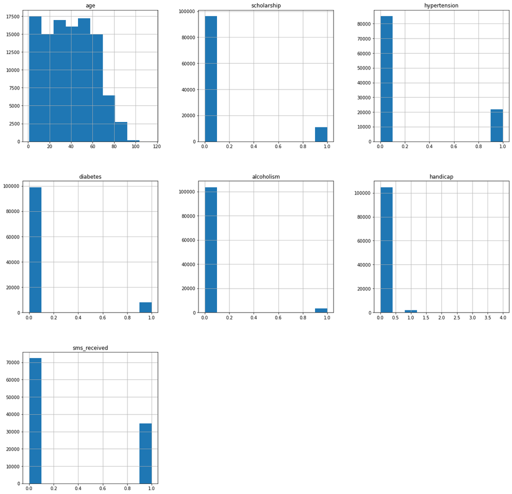

```python
#The best way to have an overview exploration is by using histogram over the whole dataset using .hist()
#figsize is set that way to make it big enough to be visualized clearly without any diffculties.
df.hist(figsize=(20,20));
```

### Cont. 1D exploratory data analysis

As some variables didn't appear in the general histogram I went for going for these variables individually through value counts. This includes the gender, neighbourhood and the patients that didn't show up to the appointment. This will be done through calculating the value counts using function I will make to value counts and barplot them.

```python
#plootie takes the variables that weren't able to be put in the overview histogram and start to use the value counts each
    #var is used to take a variable name from the dataset to be used for bar plots to have insight
    #about the frequencies of value counts of each variable in the dataset.

    #data refers to the dataframe which is df and var refers to the column we want to barplot.

def plootie(data,var):
    #val is the variable name for storing the value counts.

    val=data[var].value_counts()

    #ploot refer to the plot we will have as a result.

    ploot=val.plot(kind='bar')

    return val,ploot
```

#### Barplot for gender value counts

```
(F    70118
 M    36869
 Name: gender, dtype: int64,
 <AxesSubplot:>)
```

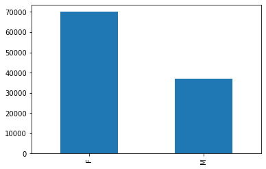

```python
#Using plootie I just created you can see the number of females and males in our dataset
#and even can see a barplot for the gender value counts.
plootie(df,'gender')
```

#### Barplot for no_show

```
(No     85307
 Yes    21680
 Name: no_show, dtype: int64,
 <AxesSubplot:>)
```

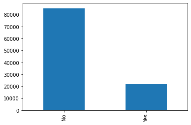

```python
#Using plootie I just created you can see the number of patients showing up and not showing upin our dataset
#and even can see a barplot for the no_show value counts,
#where 'No' implies that the patient shows up and 'Yes' meaning the patient doesn't come to the appointment.
plootie(df,'no_show')
```

```python
#Value counts of the patients' neighbourhoods, since plootie won't work for it as this one requires different plot.
    #We can see that a lot of patients come from 'Jardim Camburi'  neighbourhood.
neighbourhood_counts=df['neighbourhood'].value_counts()
neighbourhood_counts
```

```
Jardim Camburi                 7586
Maria Ortiz                    5563
Resistência                    4235
Jardim Da Penha                3851
Itararé                        3412
                               ...
Ilha Do Boi                      35
Ilha Do Frade                    10
Aeroporto                         8
Ilhas Oceânicas De Trindade       2
Parque Industrial                 1
Name: neighbourhood, Length: 81, dtype: int64
```

#### Horizontal Barplot for patients' neighbourhoods

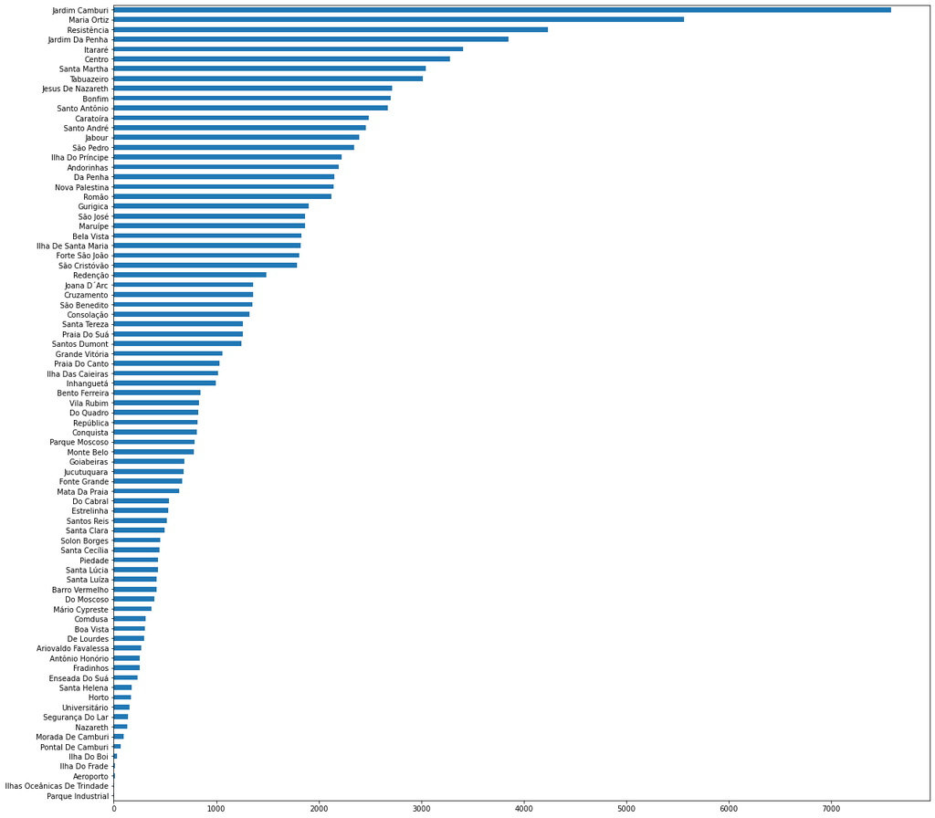

```python
#I used plot with barh kind meaning horizontal barplot which gives the best visualization for this variable in my opinion,
#making it look so illustrative specially with the invert_yaxis() letting you see the counts in ascending order and in clear manner.
neighbourhood_counts.plot(kind='barh',figsize=(20,20)).invert_yaxis();
```

### Looking for a relationship (2D exploratory analysis)

-Here I will group the data by the patients showing up or not showing up and see their correlation with the other vairable in order to come up with insight what might correlates with the patients not showing up. -According to the overview plot and the other plots we will be doing almost everyone of the variables expect for handicapped patients as we can see that the non-handicapped are way too dominant in the dataset making it so hard to use it to look for a relationship. -Add to that alcoholic patients seems to be very low in number to even use for such anaylsis so we might exclude it from going through 2D anaylsis.

-From here we can make 2 new variables to use for analyzing why a lot of patients don't show up according to the other variables. -'show' for the patients that shows up and 'not_show' for the patients that didn't show up.

```python
#not_show is created using .query() as I filter the patients not showing up in this new variable.
not_show=df.query('no_show =="Yes"')
#After this we group the data by the no_show column using groupby()
not_show.groupby('no_show')
show=df.query('no_show =="No"')
show.groupby('no_show')
```

```
<pandas.core.groupby.generic.DataFrameGroupBy object at 0x000002070760B190>
```

```python
#corry is a function that looks for correlation between the variable and each other where:
    #para is the parameter we will use to find correlation with showing up to the appointment or not showing up.
    #data_1 will refer to the patients 'showing up' , data_2 will refer for the patients 'not showing up'.
    #cory_1 and cory_2 represents the plot coming out of data we inputted to be inspected letting us see different aspects
    #of the data:

        #cory_1 will be made in blue with alpha (which reflects the transparency) into 0.4 and and putting the 'Showing up'
        #as label which will be used for the legend as well as they will represent patients showing up.

        #cory_2 will be made in red with alpha set to 0.7 and and putting the 'Not showing up'
        #as label which will be used for the legend as well as they will represent patients not showing up.

    #Also we have legends by using plt.legend() that depends on the labels I stated in cory_1 and cory_2 for the colors
    #to give insight about the plot information.

#Both cory_1,_2 will be combined for 2D plot for more exploratory data analyis as the output of this function by using return cory_1,cory_2.
#Using those colors,labels, alpha and legend they visualization will be clear and easy to be presented to the viewer.
def corry(data_1,data_2,para):
    cory_1=data_1[para].value_counts().plot(kind='bar',alpha=0.4,color='blue',label='Showing up',title='Patients showing up according to {}.'.format(para))
    cory_2=data_2[para].value_counts().plot(kind='bar',alpha=0.7,color='red',label='Not showing up')
    plt.legend()
    return cory_1,cory_2
```

#### 2D barplot of patients showing up according to gender

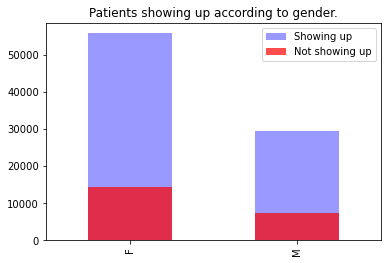

```python
#Now I use corry to let you see the 2D barplot between patients showing up and not showing up according to gender.
corry(show,not_show,'gender');
```

-Visually we can tell that nearly the number of patients showing up in the females are nearly twice the number of showing up in males and in the not showing up we can say it is nearly twice as well. -So, if we are looking to certain correlation we can find that the gender doesn't affect the action of patient showing up or not.

-I added here frequencies to let the viewer see that they females are nearly twice in showing up and not showing up according to the case study letting the viewer have insight that the gender doesn't have effect on patient showing up or not.

-Frequencies of patients showing up according to gender.

```python
#Here by grouping by gender and look in no_show in the filter show dataframe you can see the females and males patients
#showing up to the appointment through .describe()
show.groupby('gender')['no_show'].describe()
```

| gender | count | unique | top | freq |
| --- | --- | --- | --- | --- |
| F | 55843 | 1 | No | 55843 |
| M | 29464 | 1 | No | 29464 |

-Frequencies of patients not showing up according to gender.

```python
#Here by grouping by gender and look in no_show in the filter not_show dataframe you can see the females and males patients
#not showing up to the appointment through .describe()
not_show.groupby('gender')['no_show'].describe()
```

| gender | count | unique | top | freq |
| --- | --- | --- | --- | --- |
| F | 14275 | 1 | Yes | 14275 |
| M | 7405 | 1 | Yes | 7405 |

#### 2D barplot of patients showing up according to hypertension.

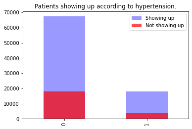

```python
#Now I use corry to let you see the 2D barplot between patients showing up and not showing up according to hypertension.
corry(show,not_show,'hypertension');
```

-According to the plot we see we find that patients having hypertension and their frequency ratio of showing up is considered higher than those how aren't hypertensive giving an insight that hypertension have 'negative correlation' in our group study.

#### 2D barplot of patients showing up according to diabetes.

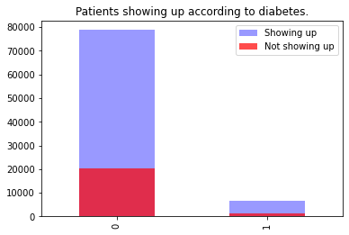

```python
#In here, I use corry to let you see the 2D barplot between patients showing up and not showing up according to diabetes.
corry(show,not_show,'diabetes');
```

-We can see here that the case here is similar to hypertension where people having diabetes frequency ratio of showing up is higher than those how aren't diabetic. -But we can't take it as a very relevant relationship as the diabetic patients are low in number.

#### 2D barplot of patients showing up according to scholarship subsidy.

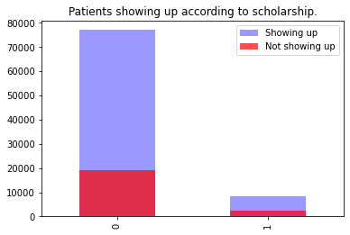

```python
#Meanwhile, as I use corry to let you see the 2D barplot between patients showing up and not showing up according to scholarship.
corry(show,not_show,'scholarship');
```

-We can see here that patients having scholarship subsidy or not , don't have a clear relationship with showing up or not.

#### 2D barplot of patients showing up accodring to sms recieved

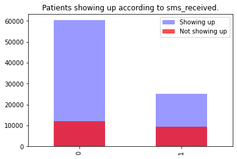

```python
#Finally,I use corry to let you see the 2D barplot between patients showing up and not showing up according to SMS recieved by patients.
corry(show,not_show,'sms_received');
```

-We notice even tho there are a lot of patients that didn't recieve sms they seem to show up more than the people recieving sms. -Meaning that there might be a slight positive correlation between that receiving sms might give a bit of negative impact of showing up to the appointment.

#### 2D barplot of patients showing up according to neighbourhood.

I used horizontal barplot again for better data visualization.

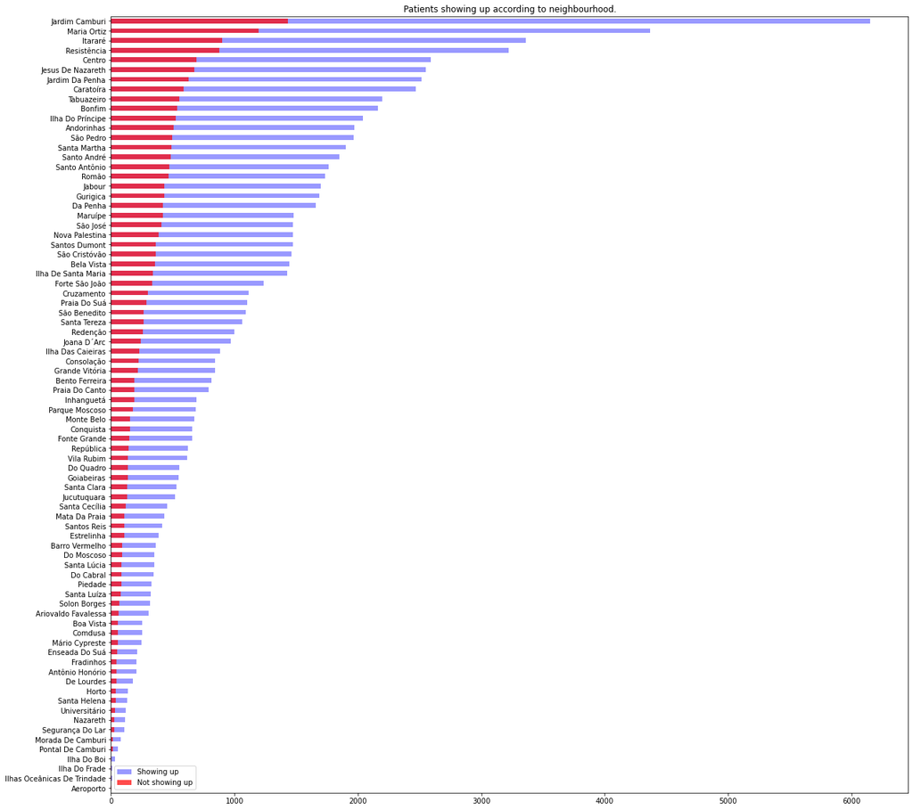

```python
#Now, since corry won't work on neighbourhood this took more effort but I nearly wrote the same conditions, expect for the type
#of plot I am using and inverting its y-axis again for clear data representation.


#Even the labels, colors, alpha and legends are set the same as corry function above.

#To do that I first used the show dataframe which is grouped by no_show column and extract the neighbourhood column
#counting the values to be used for the plot to be visualized.


show['neighbourhood'].value_counts().plot(kind='barh',alpha=0.4,color='blue',label='Showing up',title='Patients showing up according to neighbourhood.',figsize=(20,20))

#Then, I used not_show dataframe that contains patients not showing up to appointments and extract their neighbourhood column
#to visualize their value counts compared to the ones who showed up.

#figsize large enough to visualize the data with no diffculties.

#invert_yaxis for more clear data representation.

not_show['neighbourhood'].value_counts().plot(kind='barh',alpha=0.7,color='red',label='Not showing up',figsize=(20,20)).invert_yaxis()
plt.legend();
```

-As we can see in this beautiful plot that the number of patients not showing up according to the neighbourhood is almost well distributed with the ones showing making neighbourhood unable to get that much of a relationship between it and patients not showing up.

#### 2D histogram for showing up according to age.

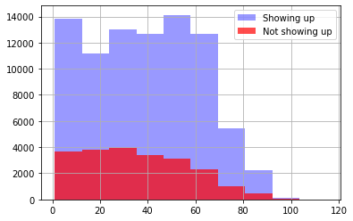

```python
#For age the best way to look it up is through a histogram so by using the show dataframe containing the patients
#who shows up to appointments, who are grouped by no_show column and then I used the 'age' column to start to them up
#in the histogram using .hist() with blue color and alpha set to 0.4 for clear representation and label='Showing up'.

#Meanwhile the ones who didn't show up are grouped in not_show datafram and I extracted their age column to use histogram using
#.hist() upon them letting me see them with red color clearly by alpha set to 0.7 and label='Not showing up'
show['age'].hist(alpha=0.4,color='blue',label='Showing up')
not_show['age'].hist(alpha=0.7,color='red',label='Not showing up')
plt.legend();
```

## Conclusions

-After analyzing the relationships between the characteristics of the patients that might affect them showing up or not, we can find that there was a negative correlation between patients having some chronic diseases like hypertension and diabetes but still we can't see this as a very relevant relationship.

-We also saw that people receiving SMS of their appointment seems to not show up to the appointment which might be correlated as they might need to be called for appointment confirmation, still we can't take this as a cause as well since we can see that patients who didn't get SMS seems to show up with higher frequency ratio even though they didn't receive SMS, yet we can't ignore that it was the value with the most significant correlation compared to the other variables.

-Yet, after all of these conclusions I find the dataset is unable to answer these questions of why the patients not showing up more clearly as there were a huge number of the patients having wrong values as their age being 0 and -1 and it was about 3.4k patients which is statistically is a large number to be cleaned out of data, and they might the values that could have changed the representation and the statistics of the dataset. Add to that there were some characteristics where the data was so skewed on one side making it hard to look for a clear pattern of correlation, making me face a lot of diffculties and limitations of giving you a clear conclusion as viewer.